# Assessment of TRMM vs PACRAIN raw data conditioned to Weather Types

Óscar Mirones Alonso

```r
if (dir.exists("C:/Users/usuario/Desktop/TRMM-Calibration/Data")) {
  dir <- "C:/Users/usuario/Desktop/TRMM-Calibration/Data"
}else{
  dir <- "/vols/seal/oceano/gmeteo/WORK/juaco/trmm/clustering"
}
```

```r
knitr::opts_knit$set(root.dir = dir)
```

# Preview

In this part everything necessary prior to the analysis is collected. The libraries are loaded, the data and some function necessary for the calculation of some validation index is implemented.

First, libraries are loaded

```r
library(loadeR)
library(transformeR)
library(downscaleR)
library(visualizeR)
library(convertR)
library(ncdf4)
library(climate4R.value)
library(magrittr)
library(evd)
library(formattable) #neccessary to create tables with colors
library(lubridate) #neccessary to calculate differences in years between dates
library(lattice)
library(ggplot2)
library(raster)
library(rasterVis)
library(sp)
```

```r
set.seed(42)
```

PCA data from other notebook is loaded.

```r
load("pca.RData")
```

Reanalysis data is loaded to compute later the spatialPlot of the clusters.

```r
load("pp_reanalysis.RData")
```

Here a subsetting is made with the goal of restrict the number of PCs involved (since PCs’number related with precipitation is over 2000). So, the variance explained is 0.75,0.9 and 0.9 for precipitation, sea level pressure and difference sea level pressure respectively.

```r
idx.tp <- which(attributes(pca$tp[[1]])$explained_variance >= .75)[1]
idx.msl <- which(attributes(pca$msl[[1]])$explained_variance >= .9)[1]
idx.diff.msl <- which(attributes(pca$diff_msl[[1]])$explained_variance >= .9)[1]

pca.matrix <- cbind(pca$tp[[1]]$PCs[,1:idx.tp],pca$msl[[1]]$PCs[,1:idx.msl],pca$diff_msl[[1]]$PCs[,1:idx.diff.msl])
```

It is good to preview the intracluster error against the number of clusters computed. The selection made is k=5 and k=6.

```r
totWithinss <- c(1:15)

for(i in 1:15){
  kmModel<- kmeans(pca.matrix, centers = i, nstart = 1)
  totWithinss[i]<- kmModel$tot.withinss

}
```

```
did not converge in 10 iterationsdid not converge in 10 iterations
```

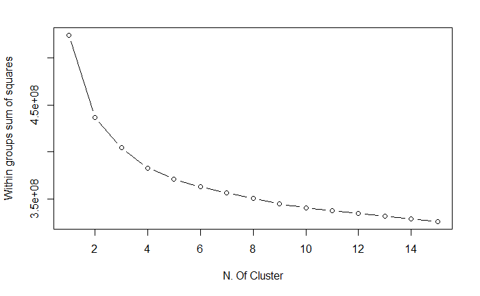

```r
plot(x=1:15,y=totWithinss,type="b", xlab="N. Of Cluster",ylab="Within groups sum of squares")
```

So, the kmeans model is computed and saved for the optimum k.

```r
k = 5
load('kmModel5.RData')
```

Station locations are plotted with their corresponding codes.

```
[2021-04-20 10:02:18] Doing inventory ...
[2021-04-20 10:02:19] Done.
```

| stationID | longitude | latitude | altitude | name |
| --- | --- | --- | --- | --- |
| NZ75400 | -178.117 | -14.3167 | 36 | Kolopelu(Wallis_and_Futuna) |
| NZ82400 | -169.933 | -19.0667 | 59 | Hakupu(Niue) |
| NZ84317 | -159.800 | -21.2000 | 4 | RarotongaIA(Cook_Island) |
| NZ99701 | -177.933 | -29.2333 | 49 | Bells_Beach(New_Zealand) |
| SP00646 | -168.300 | -17.7167 | 24 | ocean_buoy |
| US14000 | -170.767 | -14.3000 | 408 | Aoloau(American_Samoa) |
| US14690 | -170.700 | -14.3167 | 3 | Aoloau(American_Samoa) |

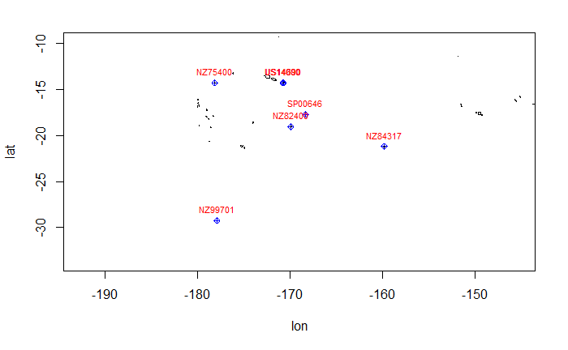

```r
stationInfo("SP_ascii.zip")
```

```r
lista <- lapply(1:k, function(x) subsetDimension(pp_reanalysis, dimension = "time", indices = which(kmModel5$cluster == x)) %>% climatology())
```

```
[2021-06-11 16:43:40] - Computing climatology...
[2021-06-11 16:43:43] - Done.
[2021-06-11 16:43:45] - Computing climatology...
[2021-06-11 16:44:10] - Done.
[2021-06-11 16:44:18] - Computing climatology...
[2021-06-11 16:44:34] - Done.
[2021-06-11 16:44:35] - Computing climatology...
[2021-06-11 16:44:37] - Done.
[2021-06-11 16:44:42] - Computing climatology...
[2021-06-11 16:44:53] - Done.
```

[figure not shown]

```r
kmedias.pp <- bindGrid(lista, dimension = "member", skip.temporal.check = TRUE)

spatialPlot(kmedias.pp,backdrop.theme = 'countries', rev.color = T, as.table = T, names.attr = paste("Days in cluster", 1:k, ":",kmModel5$size[1:k]))
```

```
Calculating areal weights...
[2021-04-20 10:03:06] - Aggregating lat dimension...
[2021-04-20 10:04:04] - Done.
[2021-04-20 10:04:04] - Aggregating lon dimension...
[2021-04-20 10:04:04] - Done.
```

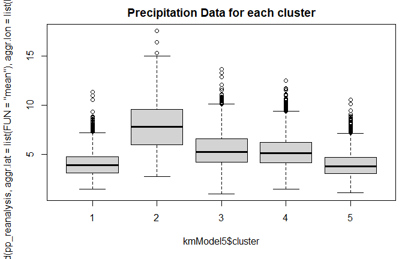

```r
b <- boxplot(aggregateGrid(pp_reanalysis, aggr.lat = list(FUN = "mean"), aggr.lon = list(FUN = "mean"))$Data~kmModel5$cluster, main = "Precipitation Data for each cluster")
```

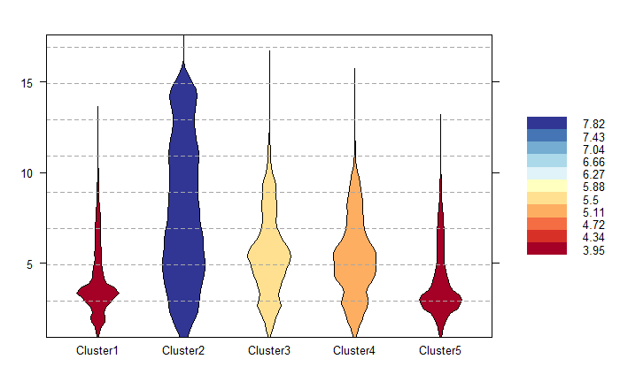

```r
violinPlot("Cluster1" = subsetGrid(kmedias.pp, members = 1), "Cluster2" = subsetGrid(kmedias.pp, members = 2),"Cluster3" = subsetGrid(kmedias.pp, members = 3),"Cluster4" = subsetGrid(kmedias.pp, members = 4), "Cluster5" = subsetGrid(kmedias.pp, members = 5))
```

MaxReturnValue function is computed to calculate the Maximum Return Value in 20 years index.

```r
MaxReturnValue <- function(data){
  #library(lubridate)
  #nyears <- round(time_length(difftime(cal.madrid.eqm$Dates$end[length(cal.madrid.eqm$Dates$end)], cal.madrid.eqm$Dates$start[1]),"years"))
  nyears <- 20
  data.maxYear <- aggregateGrid(redim(data), aggr.y = list(FUN = "max",na.rm = TRUE))

  data.maxrv <- climatology(data, clim.fun = list(FUN = "mean", na.rm = T))

  auxData <- data.maxYear$Data
  auxData[which(is.infinite(auxData))] <- NA

  if (any(!is.na(auxData))){
      auxGEV <- fgev(auxData)
      if ((auxGEV$estimate[3] - auxGEV$std.err[3] < 0) & (0  < auxGEV$estimate[3] + auxGEV$std.err[3])){
        auxGEV <- fgev(auxData, shape = 0)
        auxRV <- qgev(1-1/nyears, loc = auxGEV$estimate[1], scale = auxGEV$estimate[2], shape = 0)
      }else{
        auxRV <- qgev(1-1/nyears, loc = auxGEV$estimate[1], scale = auxGEV$estimate[2], shape = auxGEV$estimate[3])
      }
      data.maxrv <- as.numeric(auxRV)
      names(data.maxrv) <- paste("RV",nyears,"_max", sep = "")
  }
  return(data.maxrv)
  }
```

```r
severalQQplot <- function(obs, trmm , obs.cl1, obs.cl2,obs.cl3,obs.cl4,
                          obs.cl5,wt1, wt2, wt3, wt4, wt5,obs.cl6, wt6){
  qqplot(obs$Data[!is.na(obs$Data)], trmm$Data[!is.na(obs$Data)], main = paste(station.obs$Metadata$name), xlab = "Observed (mm)", ylab = "Predicted (mm)", col = "black", pch = 2, cex = .5)

abline(a = 0, b = 1)

points(sort(obs.cl1$Data[!is.na(obs.cl1$Data)]), sort(wt1$Data[!is.na(obs.cl1$Data)]), col = "pink", pch = 4, cex = .5)
points(sort(obs.cl2$Data[!is.na(obs.cl2$Data)]), sort(wt2$Data[!is.na(obs.cl2$Data)]), col = "red", pch = 4, cex = .5)
points(sort(obs.cl3$Data[!is.na(obs.cl3$Data)]), sort(wt3$Data[!is.na(obs.cl3$Data)]), col = "blue", pch = 19, cex = .5)
points(sort(obs.cl4$Data[!is.na(obs.cl4$Data)]), sort(wt4$Data[!is.na(obs.cl4$Data)]), col = "gold", pch = 19, cex = .5)
points(sort(obs.cl5$Data[!is.na(obs.cl5$Data)]), sort(wt5$Data[!is.na(obs.cl5$Data)]), col = "forestgreen", pch = 19, cex = .5)

if(!is.null(wt6)){
  points(sort(obs.cl6$Data[!is.na(obs.cl6$Data)]), sort(wt6$Data[!is.na(obs.cl6$Data)]), col = "cyan", pch = 4, cex = .5)
  legend("topleft", legend = c("TRMM","WT1", "WT2","WT3","WT4","WT5","WT6"), pch = c(2,4,4,19,19,19,4), col = c("black", "pink","red","blue","gold","forestgreen","cyan"), cex = .75)
}else{
  legend("topleft", legend = c("TRMM","WT1", "WT2","WT3","WT4","WT5"), pch = c(2,4,4,19,19,19), col = c("black", "pink","red","blue","gold","forestgreen"), cex = .75)
}



grid()
}
```

Finally, PACRAIN and TRMM precipitation data is loaded using loadeR funciton loadStationData. This data readout is easy and fast since both datasets are established in a ASCII format for each of the 7 PACRAIN station existing in our target area. Obviously, precip_obs is related with PACRAIN data and precip_trmm with TRMM data.

```r
precip_obs <- loadStationData("SP_ascii.zip", var = "precip_obs")
```

```
[2021-04-20 10:04:06] Loading data ...
Warning in .Internal(gc(verbose, reset, full)) :
  closing unused connection 3 (SP_ascii.zip:SP_ascii/precip_obs.txt)
[2021-04-20 10:04:07] Retrieving metadata ...
the condition has length > 1 and only the first element will be used[2021-04-20 10:04:07] Done.
```

```r
precip_trmm <- loadStationData("SP_ascii.zip", var = "precip_trmm")
```

```
[2021-04-20 10:04:07] Loading data ...
Warning in .Internal(gc(verbose, reset, full)) :
  closing unused connection 3 (SP_ascii.zip:SP_ascii/precip_trmm.txt)
[2021-04-20 10:04:08] Retrieving metadata ...
the condition has length > 1 and only the first element will be used[2021-04-20 10:04:08] Done.
```

```r
pp_reanalysis <- subsetYears(pp_reanalysis, years = 1998:2019)
```